# Exploratory Data Analysis

Shiying Wang

5/6/2020

### 1. Data Loading and Cleaning

```r
linkages <- read.csv("linkages.csv", check.names = FALSE)
linkages <- linkages[ ,-10] # remove the extra column
glimpse(linkages)
```

```
## Rows: 9,602
## Columns: 9
## $ country          <fct> Afghanistan, Afghanistan, Afghanistan, Afghanistan, …
## $ iso              <fct> AFG, AFG, AFG, AFG, AFG, AFG, AFG, AFG, AFG, AFG, AF…
## $ goal             <fct> Goal 6 - Clean Water and Sanitation, Goal 15 - Life …
## $ target           <fct> 6.5, 15.5, 15.7, 7.1, 7.2, 12.2, 2.4, 7.3, 7.3, 13.2…
## $ ndc_text         <fct> "Adaptive and integrated land and water management "…
## $ status           <fct> Future, Future, Future, Future, Future, Future, Futu…
## $ sector           <fct> "Forest and land use", "Forest and land use", "Fores…
## $ climate_response <fct> Adaptation, Adaptation, Adaptation, Mitigation, Miti…
## $ type             <fct> Action, Action, Action, Action, Action, Action, Need…
```

```r
# generate unique id for each row
id <- rownames(linkages)
linkages <- cbind(id=id, linkages)

# convert character to factor
linkages$id <- as.factor(linkages$id)

# clean the "goal" variable
levels(linkages$goal)
```

```
##  [1] "Goal 1 - No Poverty "
##  [2] "Goal 10 - Reduced Inequalities"
##  [3] "Goal 11 - Sustainable Cities and Communities "
##  [4] "Goal 12 - Responsible Consumption and Production"
##  [5] "Goal 12 - Responsible Consumption and Production "
##  [6] "Goal 13 - Climate Action"
##  [7] "Goal 14 - Life Below Water"
##  [8] "Goal 15 - Life on Land"
##  [9] "Goal 16 - Peace, Justice and Strong Institutions"
## [10] "Goal 17 - Partnerships for the Goal"
## [11] "Goal 2 - Zero Hunger"
## [12] "Goal 3 - Good Health and Well-being"
## [13] "Goal 4 - Quality Education"
## [14] "Goal 5 - Gender Equality"
## [15] "Goal 6 - Clean Water and Sanitation"
## [16] "Goal 7 - Affordable and Clean Energy"
## [17] "Goal 8 - Decent Work and Economic Growth"
## [18] "Goal 9 - Industry, Innovation and Infrastructure"
## [19] "Goal 9 - Industry, Innovation and Infrastructure "
```

```r
# There should be 17 SDGs but here we have 19 levels. So we need to clean the current factors list.
levels(linkages$goal)[levels(linkages$goal)=='Goal 1 - No Poverty '] <- 'Goal 1 - No Poverty'
levels(linkages$goal)[levels(linkages$goal)=='Goal 9 - Industry, Innovation and Infrastructure '] <- 'Goal 9 - Industry, Innovation and Infrastructure'
levels(linkages$goal)[levels(linkages$goal)=='Goal 11 - Sustainable Cities and Communities '] <- 'Goal 11 - Sustainable Cities and Communities'
levels(linkages$goal)[levels(linkages$goal)=='Goal 12 - Responsible Consumption and Production '] <- 'Goal 12 - Responsible Consumption and Production'

# change the order of different levels
linkages$goal <- factor(linkages$goal, levels = c("Goal 1 - No Poverty", "Goal 2 - Zero Hunger",
                                                  "Goal 3 - Good Health and Well-being", "Goal 4 - Quality Education",
                                                  "Goal 5 - Gender Equality", "Goal 6 - Clean Water and Sanitation",
                                                  "Goal 7 - Affordable and Clean Energy", "Goal 8 - Decent Work and Economic Growth",
                                                  "Goal 9 - Industry, Innovation and Infrastructure",
                                                  "Goal 10 - Reduced Inequalities", "Goal 11 - Sustainable Cities and Communities",
                                                  "Goal 12 - Responsible Consumption and Production", "Goal 13 - Climate Action",
                                                  "Goal 14 - Life Below Water", "Goal 15 - Life on Land",
                                                  "Goal 16 - Peace, Justice and Strong Institutions",
                                                  "Goal 17 - Partnerships for the Goal"))


# check again
levels(linkages$goal)
```

```
##  [1] "Goal 1 - No Poverty"
##  [2] "Goal 2 - Zero Hunger"
##  [3] "Goal 3 - Good Health and Well-being"
##  [4] "Goal 4 - Quality Education"
##  [5] "Goal 5 - Gender Equality"
##  [6] "Goal 6 - Clean Water and Sanitation"
##  [7] "Goal 7 - Affordable and Clean Energy"
##  [8] "Goal 8 - Decent Work and Economic Growth"
##  [9] "Goal 9 - Industry, Innovation and Infrastructure"
## [10] "Goal 10 - Reduced Inequalities"
## [11] "Goal 11 - Sustainable Cities and Communities"
## [12] "Goal 12 - Responsible Consumption and Production"
## [13] "Goal 13 - Climate Action"
## [14] "Goal 14 - Life Below Water"
## [15] "Goal 15 - Life on Land"
## [16] "Goal 16 - Peace, Justice and Strong Institutions"
## [17] "Goal 17 - Partnerships for the Goal"
```

In our current NDC-SDG linkages database, there are already 9602 observations coming from the analysis on over 190 countries’ NDC submissions. For each row, we have the data for nine variables: **country** - the country name; **iso** - the three digit ISO code for that country; **ndc_text** - the specific text extracted from the NDC submission; **goal** - the tagged Sustainable Development Goal for the text from that country’s NDC document; **target** - the more specific tagged target under that Sustainable Development Goal; **status** - whether the policy is an existing one or aims to be developed in the future; **sector** - which sector does the policy lie in; **climate_response** - whether it is an adaptation measure or a mitigation one; **type** - whether the text is identifying a specific action or just a needs & gaps to implement other actions.

In our analysis, the most used variables will be **ndc_text**, **goal** and **target**.

### 2. Exploratory Data Analysis

#### 2.1 Treemap: Count Statistics for NDC-SDG Linkages

First, we could use tree maps to visualize the count of sustainable development goals mentioned in countries’ Nationally Determined Contribution submissions. We can tell from the tree map that, the most frequently mentioned sustainable development goals in countries’ NDC submissions are **Goal 7** - Affordable and Clean Energy, **Goal 13** - Climate Action, **Goal 15** - Life on Land and **Goal 2** - Zero Hunger.

More Specifically, we can further conclude that within each SDG, which targets are mentioned the most frequently. For example, under **Goal 7** - Affordable and Clean Energy, the most popular targets are **Target 7.2** - By 2030, increase substantially the share of renewable energy in the global energy mix, and **Target 7.3** - By 2030, double the global rate of improvement in energy efficiency.

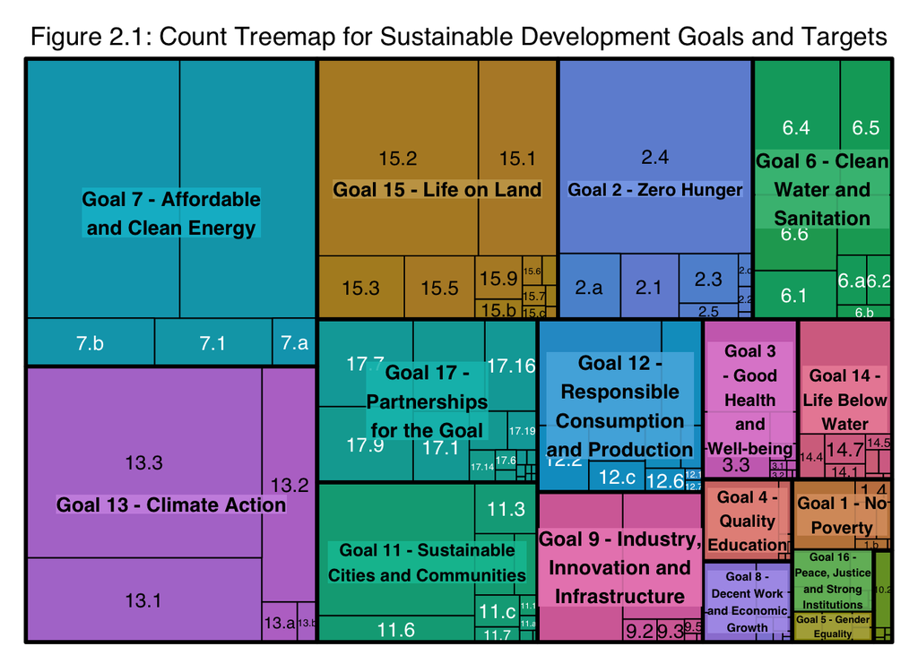

```r
# library
library(treemap)

# Build Dataset
## only keep columns "goal" and "target"
tree_linkages <- linkages[, c(4,5)] %>%
  group_by(goal) %>%
  count(target)

tree_linkages <- tree_linkages[-1, ]

# treemap
treemap(tree_linkages,
        index = c("goal",
                  "target"),
        vSize = "n",
        title = "Figure 2.1: Count Treemap for Sustainable Development Goals and Targets")
```

#### 2.2 Wordcloud: Trending Words for Each Sustainable Development Goals

Then we can do some preliminary text processing and create a word cloud to see the trending words for each sustainable development goals linkages.

Here we use the most frequently tagged goal: **Goal 7** - Affordable and Clean Energy, as an example.

```r
goal7 <- linkages %>%
  filter(goal == "Goal 7 - Affordable and Clean Energy")

goal7_txt <- goal7$ndc_text

# remove special characters
goal7_txt_chrs <- gsub("[^A-Za-z]", " ", goal7_txt)

# convert to corpus
goal7_corpus <- goal7_txt_chrs %>%
  VectorSource() %>%
  Corpus()

head(goal7_corpus$content)
```

```
## [1] "Behavioural change and opportunities for provision and development of alternative and renewable energy sources for     of the rural population above existing levels        in order to contribute to a reduction in the unsustainable usage of natural resources and decreasing the strong reliance…
## [2] "Behavioural change and opportunities for provision and development of alternative and renewable energy sources for     of the rural population above existing levels        in order to contribute to a reduction in the unsustainable usage of natural resources and decreasing the strong reliance…
## [3] "Building codes  and standards on appliances and equipment "
## [4] "Clean cooking  heating and power projects "
## [5] "Information on available technologies  measures  and financing skills "
## [6] "National herd  reduction in fuel used  or cleaner fuel technologies "
```

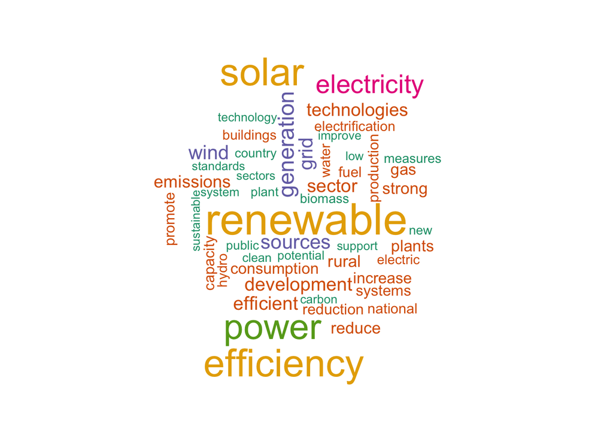

```r
# convert to lower cases
goal7_corpus_lwr <- tm_map(goal7_corpus, tolower)

# remove stop words
goal7_corpus_stpwd <- tm_map(goal7_corpus_lwr, removeWords, stopwords("english"))

# remove extra spaces
goal7_corpus_final <- tm_map(goal7_corpus_stpwd, stripWhitespace)

# visualize the popular words (top 60 words based on frequency) (using qdap) ----
term_count <- freq_terms(goal7_corpus_final, 60)

# then we can create a vector of custom stop words based on the results
custom_stop <- c("energy", "use", "will", "mw", "pv", "sub", "including", "s",
                 "li", "based") # I exclude the word "energy" here to keep the count of words at the relatively same scale.

# remove custom stop words
goal7_corpus_refined <- tm_map(goal7_corpus_final, removeWords, custom_stop)

# creating a colorful word cloud (using RColorBrewer)
wordcloud(goal7_corpus_refined, max.words = 50,
          colors = brewer.pal(6, "Dark2"),
          scale = c(3, 0.5),
          random.order = TRUE,
          main = "Figure 2.2 Word Cloud for SDG 7, Sized by the Frequencies of the Word")
```

From the wordcloud we can tell that, energy efficiency, renewable energy, electricity and solar are the most popular words in the countries’ NDC content tagged to SDG-7.

However, wordcloud can be hard to interpret sometimes and the simple count number of words may not give us much information. So more in-depth analysis with other methods such as n-grams and tf-idf should be considered next.